# **Loan Default Prediction**

### **Decision Tree - Hyperparameter Tuning**

- Hyperparameter tuning is tricky in the sense that **there is no direct way to calculate how a change in the hyperparameter value will reduce the loss of your model**, so we usually resort to experimentation. We'll use Grid search to perform hyperparameter tuning.
- **Grid search is a tuning technique that attempts to compute the optimum values of hyperparameters.**
- **It is an exhaustive search** that is performed on the specific parameter values of a model.
- The parameters of the estimator/model used to apply these methods are **optimized by cross-validated grid-search** over a parameter grid.

**Criterion {“gini”, “entropy”}**

The function to measure the quality of a split. Supported criteria are “gini” for the Gini impurity and “entropy” for the information gain.

**max_depth**

The maximum depth of the tree. If None, then nodes are expanded until all leaves are pure or until all leaves contain less than min_samples_split samples.

**min_samples_leaf**

The minimum number of samples is required to be at a leaf node. A split point at any depth will only be considered if it leaves at least min_samples_leaf training samples in each of the left and right branches. This may have the effect of smoothing the model, especially in regression.

You can learn about more Hyperpapameters on this link and try to tune them.

https://scikit-learn.org/stable/modules/generated/sklearn.tree.DecisionTreeClassifier.html

## Building a Random Forest Classifier

**Random Forest is a bagging algorithm where the base models are Decision Trees.** Samples are taken from the training data and on each sample a decision tree makes a prediction.

**The results from all the decision trees are combined together and the final prediction is made using voting or averaging.**

```
              precision    recall  f1-score   support

           0       0.98      0.88      0.93      2140
           1       0.33      0.79      0.47       160

    accuracy                           0.87      2300
   macro avg       0.66      0.83      0.70      2300
weighted avg       0.94      0.87      0.90      2300
```

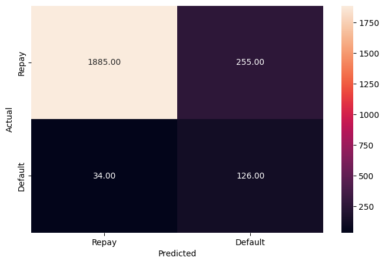

```python
forest_model = RandomForestClassifier(class_weight={0:0.07, 1:0.93}, random_state=28, criterion='gini',max_depth=4)
forest_model.fit(x_train, y_train)
y_pred = forest_model.predict(x_train)
ConfustionMatrixMetric(y_train, y_pred)
```

```
              precision    recall  f1-score   support

           0       0.97      0.89      0.93       917
           1       0.30      0.61      0.40        69

    accuracy                           0.87       986
   macro avg       0.63      0.75      0.66       986
weighted avg       0.92      0.87      0.89       986
```

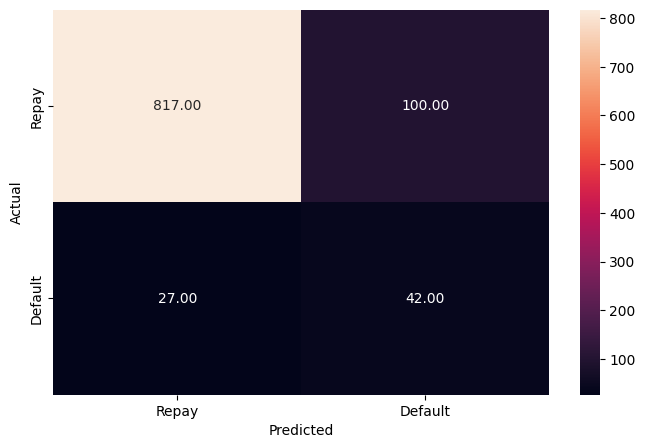

```python
y_pred = forest_model.predict(x_test)
ConfustionMatrixMetric(y_test, y_pred)
```

## Random Forest Classifier Hyperparameter Tuning

```python
# Choose the type of classifier
TunedForest = RandomForestClassifier(class_weight={0:0.07, 1:0.93}, random_state=28)

# Grid of parameters to choose from
params_rf = {
        "criterion": ['gini','entropy'],
        "max_depth": [4, 6, 8, 10],
        "min_samples_leaf": [2, 4, 6, 8],
        "min_samples_split": [2, 4, 6, 8]
}


# Type of scoring used to compare parameter combinations - precision score for class 1
scorer = metrics.make_scorer(precision_score, pos_label = 1)

# Run the grid search
grid_obj = GridSearchCV(TunedForest, params_rf, scoring = scorer, cv = 5)
grid_obj = grid_obj.fit(x_train, y_train)

# Set the classifier to the best combination of parameters
rf_estimator_tuned = grid_obj.best_estimator_
```

```python
best_params = grid_obj.best_params_
print(best_params)
```

```
{'criterion': 'gini', 'max_depth': 10, 'min_samples_leaf': 2, 'min_samples_split': 2}
```

```
              precision    recall  f1-score   support

           0       1.00      1.00      1.00      2140
           1       0.99      0.94      0.96       160

    accuracy                           1.00      2300
   macro avg       0.99      0.97      0.98      2300
weighted avg       1.00      1.00      1.00      2300
```

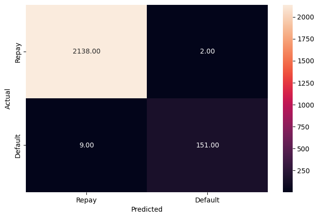

```python
rf_estimator_tuned.fit(x_train, y_train)
y_pred = rf_estimator_tuned.predict(x_train)
ConfustionMatrixMetric(y_train, y_pred)
```

```
              precision    recall  f1-score   support

           0       0.95      1.00      0.97       917
           1       0.86      0.28      0.42        69

    accuracy                           0.95       986
   macro avg       0.91      0.64      0.69       986
weighted avg       0.94      0.95      0.93       986
```

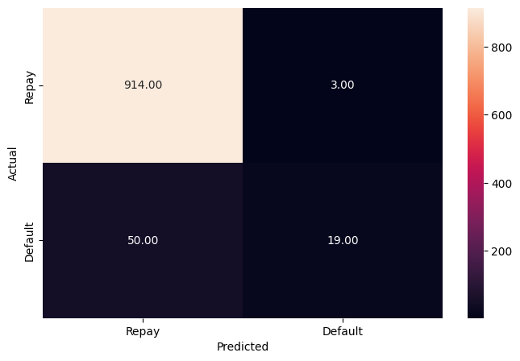

```python
y_pred = rf_estimator_tuned.predict(x_test)
ConfustionMatrixMetric(y_test, y_pred)
```

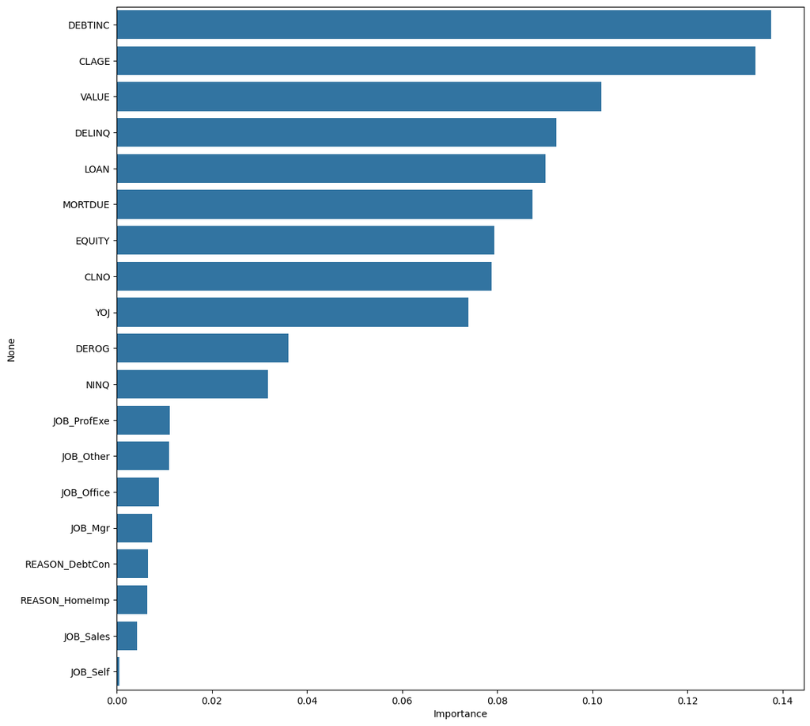

```python
importances = rf_estimator_tuned.feature_importances_
columns = X.columns
importance_data = pd.DataFrame(importances, index = columns, columns = ['Importance']).sort_values(by = 'Importance', ascending = False)
plt.figure(figsize = (13, 13))
sns.barplot(x=importance_data.Importance,y=importance_data.index)
```

## Findings and Recommendations

```
- Debt to Income Ratio has 1267 which is a little over 20%.
```

The average value of the loan 18,607 and range from 1,000 to 90,000. The average value of the property (collateral) is 101,776. The average current mortgage still due is 73,760. Applicants are primarily used the loan for Debt Consolidation or Home Improvement. Loans for Home Improvement are more likely to default. The data has significant outliers in almost all columns. There is a strong correlation between the Mortgage Due and the Value of the property. Derogatory Marks or Delinquent Marks on their credit report are the most highly correlated with Default.

Strictly based on the three highest correlated parameters suggest that

- Debt to Income ratio > 50
- Delinquent marks > 5
- Derogatory marks > 6

**1. Comparison of various techniques and their relative performance based on chosen Metric (Measure of success):**

- How do different techniques perform? Which one is performing relatively better? Is there scope to improve the performance further?
- The Random Forest after hyperparameter tuning was the best model. There is room for scope improvement with regard to cleaning and imputing the data as well as further hyperparameter tuning that could benefit the model.
- I chose Percision as the metric given that we would want to evaluate the positives. Minimizing false positives. Applicants that are predicted to default could be future analyzed by an auditor.
- The random forest model removes the ability to easily interpret the algorithm.

**2. Refined insights:**

- What are the most meaningful insights relevant to the problem?
- High Delinquency and Derogetory marks are a strong indicator of future default.

**3. Proposal for the final solution design:**

- What model do you propose to be adopted? Why is this the best solution to adopt?
- I would recommend the tuned random forest model due as a first pass method of evaluating applicants. Applicants whose loans are originally predicited to fail could be further evaluated by a trained auditor to try to capture good payers who may otherwise be turned down.
- I belive that the model can be deployed for use to identify safe applicants, and the standard auditing process be followed for applicants that are considered risky.

# Summary

Due to the high cost of approving an applicant loan that goes into default the goal is to use a data science model to better predict applicant's risk. I found that a tuned random forest model can predict those that will repay a loan with high confidence. Key factors that are being assessed in the model are the age of an applicant's credit history and their debt to income ratio. I would recommend that this model be utilized to idenfy safe applicants and continue the typical audit process with applicants the model predicts will be risky.

# Recommendations for implementation

Several applicants were approved but their data was not recorded. This is the highest risk of approval and should be corrected first.

Use of this model to focus auditors on applicants that would be deemed risky will lower workload and allow for increased scrutiny.

As additional data is collected the model can be refined with a focus on have a model that can accurately identify clients that will default.